# Ponderadores longitudinales ELSOC

## Recorte de los pesos

Una de las diferencias más importantes de los ponderadores longitudinales respecto a los ponderadores transversales es el paso extra de agregar un recorte a los valores más extremos de los pesos. Posterior a los ajustes de no respuesta y previo al ajuste respecto a totales poblacionales, se hace un recorte del 5% de los valores más extremos en la parte inferior y superior de la distribución. Es decir, si el valor observado sobrepasa el percentil 5 o el 95 se cambia el valor por dicho percentil respectivamente. Aplicar este recorte luego de las celdas de ajuste y previo a la calibración, a modo de reducir los valores extremos y asegurar que los estimadores ponderados coincidan con las proporciones poblacionales de las variables de sexo y tramo etario. La capacidad efectiva que tuvo este recorte puede verse en la parte III donde se muestran tablas con descriptivos de los pesos.

## Re-escalamientos

Los pesos longitudinales también tienen un re-escalamiento que busca equiparar la suma de los pesos al número total de observaciones de la muestra en un año en particular. Esto facilita la interpretación del valor del ponderador de un individuo bajo la forma: “cuántas personas de la muestra representa cada observación”. Hasta esta etapa, la suma de los pesos se corresponde con el total de la población objetivo, es decir el total exacto de las tablas de las proyecciones estimadas de la población hechas por el INE. Los re-escalamientos hacen que la suma de los ponderadores deje de corresponder a los totales poblacionales definidos, pero se preservan las mismas proporciones poblacionales estimadas para las variables de seco y tramo etario.

# Parte III: Distribución empírica de los pesos

La presente sección busca dar una mirada empírica a los pesos. En un primer momento se muestran los modelos utilizados en el ajuste de la no respuesta descritos en la sección anterior. Luego se ofrecen gráficos sobre la distribución de las predicciones de los valores predichos de ambos modelos.

Posterior a esto se ofrecen estadísticos de resumen a los distintos pesos que existen en el estudio ELSOC.

Las nomenclaturas de esta sección son las siguientes: *TRV Sexo* se refiere al peso transversal que ajusta solo por sexo, en la base ELSOC este el ponderador con el nombre `ponderador01`. *TRV Sexo Región* se refiere al peso transversal que ajusta por Sexo y Región, este es el ponderador que en la base ELSOC lleva el nombre `ponderador02`. *LG Total* corresponde al ponderador longitudinal pensado para el uso con el total de las observaciones de ELSOC. *LG Panel* corresponde al ponderador longitudinal pensado para el uso con cualquiera de los paneles balanceados.

## Modelamiento

### Modelos Estimados

En las siguientes pestañas se muestran los modelos estimados para hacer el ajuste de no respuesta.

Las variables son las siguientes:

Por lo mismo, en lo que respecta al cuestionario, hemos elegido las variables: *Género del entrevistado*, *Nivel Educacional del Entrevistado*, *Tramo Etario del entrevistado al inicio del estudio*,y *Estado Civil del Entrevistado*.

La variable *Género del entrevistado* toma los valores “Hombre” y “Mujer”, donde “Hombre” es la categoría base. La variable *Nivel Educacional del Entrevistado* toma los valores “Básica”,“Media”,“Técnica” y “Universitaria”, donde “Básica” es la categoría base. Para el año 2016 la moda fue la categoría “Media”. La variable *Tramo Etario del entrevistado al inicio del estudio* toma los valores “18 a 29”,“30 a 44”,“45 a 59” y “60 o más”, siendo la primera la categoría de base. Para el año 2016 la moda fue la categoría “45 a 59”. Finalmente la variable *Estado Civil del Entrevistado* toma los valores “En Pareja” y “Soltero” donde la primera categoría es la de base.

Otra fuente importante de información para ELSOC es la información territorial con la que cuenta el estudio. El Centro de Inteligencia Territorial perteneciente a la Universidad Adolfo Ibañez recopiló información geográfica de las zonas censales de los entrevistados en base a los resultados del Censo 2017. Una característica importante de estas variables es que son fijas para todos lo años del estudio y estas están agregadas a nivel de la zona censal de los entrevistados. Todas estas variables son continuas.

Adicionalmente, se evaluaron otras variables que provienen del proceso de recolección de datos. La variable *Número de visitas previo a la entrevista*. La variable *Número de items promedio sin respuesta por módulo* .

#### Muestra Original

```r
tabla_m1%>%
  select(-statistic)%>%
  mutate(across(c(estimate,std.error), ~round(.x,4)),
         sig=case_when(p.value <0.01 ~ '***',
                       p.value >0.01 & p.value <0.05 ~'**',
                       p.value >0.05 & p.value <0.1 ~'*',
                       p.value >.1 ~''))%>%
  select(-p.value)%>%
            rename(Variable=term,Coeficiente=estimate,`Err. Estándar`=std.error,Significancia=sig)%>%
DT::datatable()
```

|  | Variable | Coeficiente | Err. Estándar | Significancia |
| --- | --- | --- | --- | --- |
| 1 | Intercepto | 1.3446 | 0.0954 | *** |
| 2 | Densidad poblacional zc | 0 | 0 | *** |
| 3 | 30 a 44 años | 0.1143 | 0.0561 | ** |
| 4 | 45 a 59 años | 0.5416 | 0.0586 | *** |
| 5 | 60 o más | 0.3914 | 0.0651 | *** |
| 6 | Educ. Media | 0.1582 | 0.0524 | *** |
| 7 | Educ. Técnica | 0.065 | 0.0668 |  |
| 8 | Educ. Universitaria | 0.161 | 0.0705 | ** |
| 9 | C. Medianas | -0.5243 | 0.0688 | *** |
| 10 | C. Pequeñas | -0.0822 | 0.0773 |  |

[output cut: 13 more lines]

#### Muestra Refresco

```r
tabla_m2%>%
  select(-statistic)%>%
  mutate(across(c(estimate,std.error), ~round(.x,4)),
         sig=case_when(p.value <0.01 ~ '***',
                       p.value >0.01 & p.value <0.05 ~'**',
                       p.value >0.05 & p.value <0.1 ~'*',
                       p.value >.1 ~''))%>%
  select(-p.value)%>%
            rename(Variable=term,Coeficiente=estimate,`Err. Estándar`=std.error,Significancia=sig)%>%
DT::datatable()
```

|  | Variable | Coeficiente | Err. Estándar | Significancia |
| --- | --- | --- | --- | --- |
| 1 | Intercepto | 1.3681 | 0.1107 | *** |
| 2 | Soltero | -0.1161 | 0.0712 |  |
| 3 | 30 a 44 años | 0.0111 | 0.095 |  |
| 4 | 45 a 59 años | 0.3367 | 0.0985 | *** |
| 5 | 60 o más | 0.2363 | 0.1065 | ** |
| 6 | Escolaridad jh zc | -0.0549 | 0.022 | ** |
| 7 | NSNR 1ra ola | -0.8585 | 0.1753 | *** |
| 8 | 2021 | -0.9456 | 0.0887 | *** |
| 9 | 2022 | -0.9323 | 0.0888 | *** |
| 10 | P. Viviendas precarias zc | 0.0055 | 0.0039 |  |

[output cut: 3 more lines]

### Predicciones de los modelos según categorias

#### Muestras

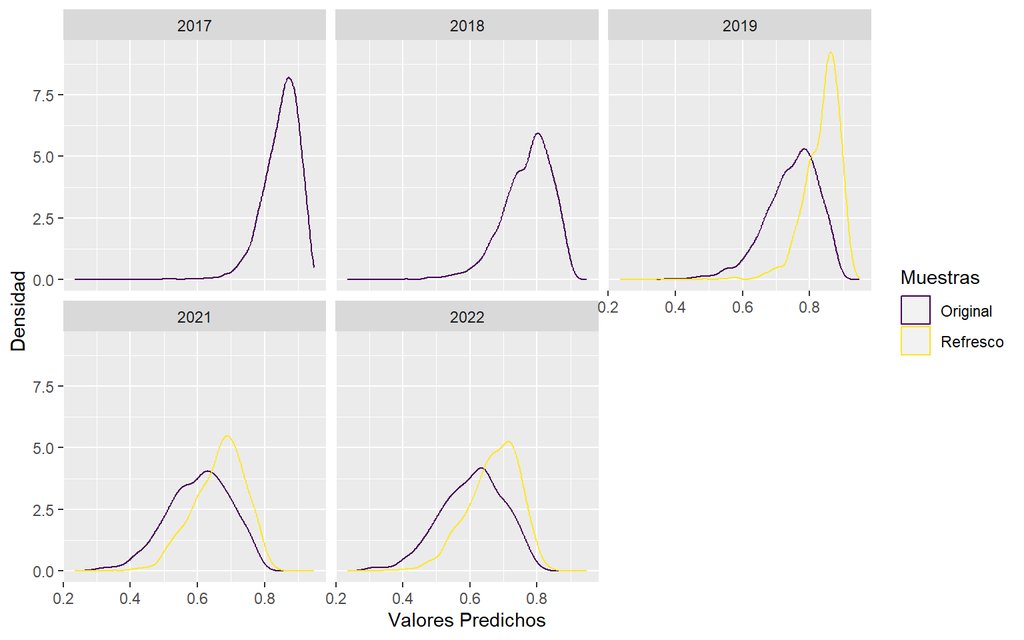

```r
grafo_preds(vars_pred[names(vars_pred)=='Muestras'])
```

#### Sexo

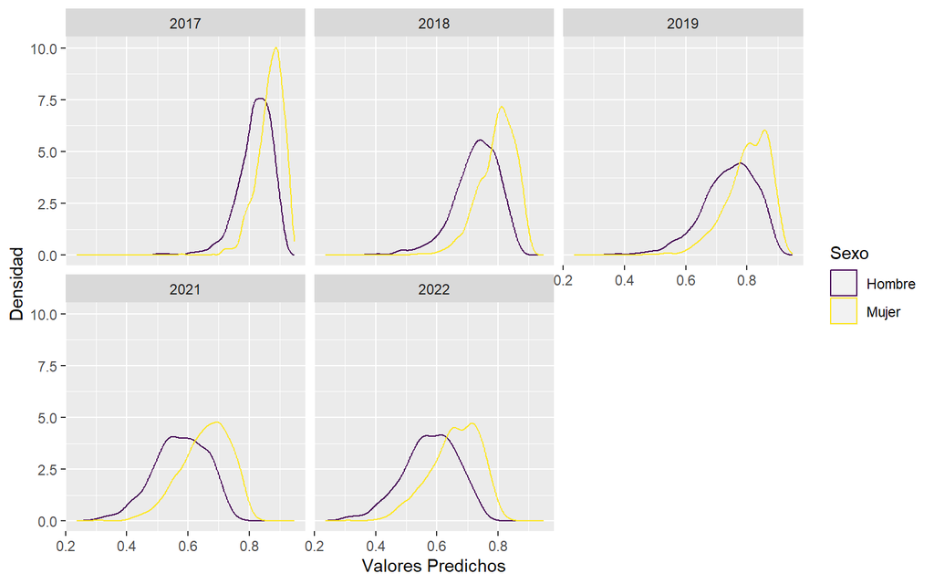

```r
grafo_preds(vars_pred[names(vars_pred)=='Sexo'])
```

#### Estratos

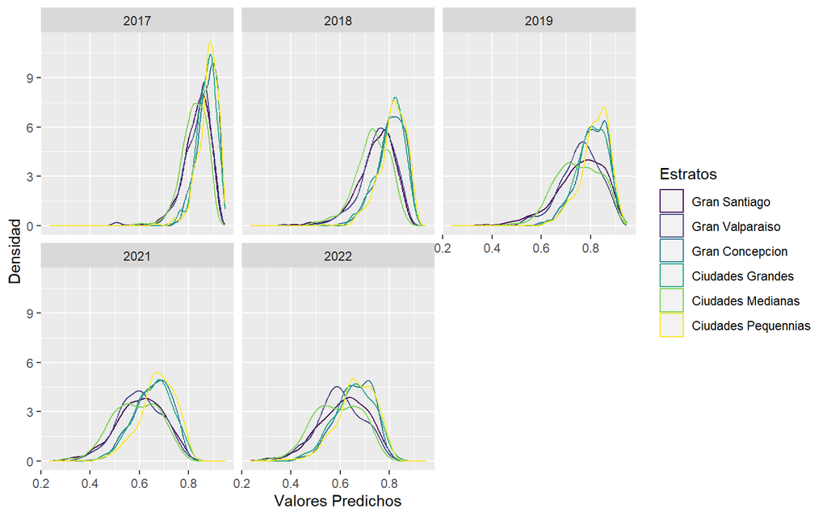

```r
grafo_preds(vars_pred[names(vars_pred)=='Estratos'])
```

#### Tramo Etario

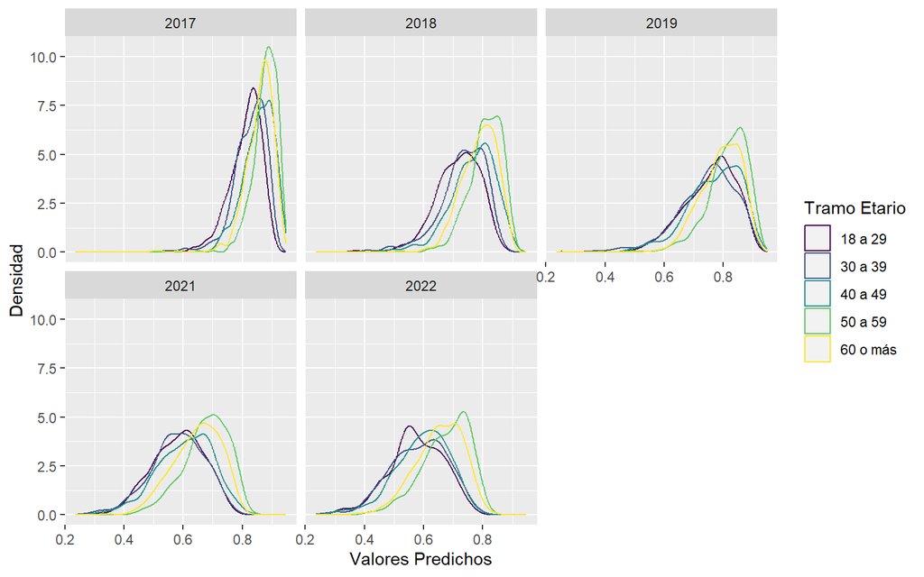

```r
grafo_preds(vars_pred[names(vars_pred)=='Tramo Etario'])
```

#### Educación

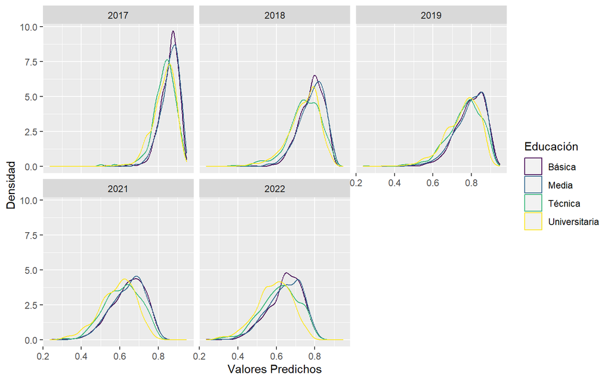

```r
grafo_preds(vars_pred[names(vars_pred)=='Educación'])
```

## Descriptivos pesos

### TRV Sexo

```r
resumen_pesos(pesos_desc[names(pesos_desc)=='TRV Sexo'])%>%DT::datatable()
```

|  | muestra | ola | n_año | peso | nas | suma | min | max | sd |
| --- | --- | --- | --- | --- | --- | --- | --- | --- | --- |
| 1 | Original | 2016 | 2927 | ponderador01 | 0 | 2967.832 | 0.002 | 12.661 | 1.1815 |
| 2 | Original | 2017 | 2473 | ponderador01 | 0 | 2504.3533 | 0 | 10.2818 | 1.1846 |
| 3 | Original | 2018 | 2229 | ponderador01 | 0 | 2229.0001 | 0.0015 | 8.2498 | 1.0603 |
| 4 | Original | 2019 | 2153 | ponderador01 | 0 | 2377.9309 | 0.0012 | 33.749 | 1.6459 |
| 5 | Original | 2021 | 1739 | ponderador01 | 0 | 2015.5338 | 0.0008 | 40.571 | 1.7794 |
| 6 | Original | 2022 | 1728 | ponderador01 | 0 | 1728 | 0.0009 | 22.9132 | 1.3511 |
| 7 | Refresco | 2018 | 1519 | ponderador01 | 0 | 1519.6765 | 0.0005 | 12.5763 | 1.0672 |
| 8 | Refresco | 2019 | 1264 | ponderador01 | 0 | 881.0692 | 0.0012 | 5.2911 | 0.6904 |
| 9 | Refresco | 2021 | 1001 | ponderador01 | 0 | 728.9704 | 0.0012 | 6.5419 | 0.783 |
| 10 | Refresco | 2022 | 1002 | ponderador01 | 0 | 1002 | 0.0021 | 13.6471 | 1.1557 |

### TRV Sexo Región

```r
resumen_pesos(pesos_desc[names(pesos_desc)=='TRV Sexo Región'])%>%DT::datatable()
```

|  | muestra | ola | n_año | peso | nas | suma | min | max | sd |
| --- | --- | --- | --- | --- | --- | --- | --- | --- | --- |
| 1 | Original | 2016 | 2927 | ponderador02 | 0 | 2968.486 | 0.001 | 12.686 | 1.2117 |
| 2 | Original | 2017 | 2473 | ponderador02 | 0 | 2505.6216 | 0 | 11.1117 | 1.2184 |
| 3 | Original | 2018 | 2229 | ponderador02 | 0 | 2229 | 0.0011 | 7.5275 | 1.1128 |
| 4 | Original | 2019 | 2153 | ponderador02 | 0 | 2356.9824 | 0.001 | 22.67 | 1.4946 |
| 5 | Original | 2021 | 1739 | ponderador02 | 0 | 1995.6622 | 0.0006 | 27.1164 | 1.6614 |
| 6 | Original | 2022 | 1728 | ponderador02 | 0 | 1728 | 0.001 | 17.5252 | 1.3841 |
| 7 | Refresco | 2018 | 1519 | ponderador02 | 0 | 1519.7024 | 0.0004 | 14.2927 | 1.1116 |
| 8 | Refresco | 2019 | 1264 | ponderador02 | 0 | 902.0175 | 0.0015 | 7.6997 | 0.7718 |
| 9 | Refresco | 2021 | 1001 | ponderador02 | 0 | 748.842 | 0.001 | 9.0488 | 0.9098 |
| 10 | Refresco | 2022 | 1002 | ponderador02 | 0 | 1002.0001 | 0.0018 | 16.9334 | 1.2525 |

### LG Total

```r
resumen_pesos(pesos_desc[names(pesos_desc)=='LG Total'])%>%DT::datatable()
```

|  | muestra | ola | n_año | peso | nas | suma | min | max | sd |
| --- | --- | --- | --- | --- | --- | --- | --- | --- | --- |
| 1 | Original | 2016 | 2927 | ponderadorlong_total | 0 | 2927 | 0.0038 | 6.6766 | 1.4097 |
| 2 | Original | 2017 | 2473 | ponderadorlong_total | 0 | 2473 | 0.0043 | 7.7356 | 1.4583 |
| 3 | Original | 2018 | 2229 | ponderadorlong_total | 0 | 2229 | 0.0038 | 9.0607 | 1.5386 |
| 4 | Original | 2019 | 2153 | ponderadorlong_total | 0 | 2153 | 0.0046 | 11.8944 | 1.611 |
| 5 | Original | 2021 | 1739 | ponderadorlong_total | 0 | 1739 | 0.0037 | 13.7425 | 1.6092 |
| 6 | Original | 2022 | 1728 | ponderadorlong_total | 0 | 1728 | 0.0037 | 14.856 | 1.7482 |
| 7 | Refresco | 2018 | 1519 | ponderadorlong_total | 0 | 1519 | 0.0044 | 4.7086 | 1.2705 |
| 8 | Refresco | 2019 | 1264 | ponderadorlong_total | 0 | 1264 | 0.008 | 9.1525 | 1.4844 |
| 9 | Refresco | 2021 | 1001 | ponderadorlong_total | 0 | 1001 | 0.0065 | 8.5228 | 1.4558 |
| 10 | Refresco | 2022 | 1002 | ponderadorlong_total | 0 | 1002 | 0.0072 | 11.8619 | 1.5274 |

### LG Panel

```r
resumen_pesos(pesos_desc[names(pesos_desc)=='LG Panel'])%>%DT::datatable()
```

|  | muestra | ola | n_año | peso | nas | suma | min | max | sd |
| --- | --- | --- | --- | --- | --- | --- | --- | --- | --- |
| 1 | Original | 2016 | 1304 | ponderadorlong_panel | 0 | 1304 | 0.0028 | 10.8272 | 1.6407 |
| 2 | Original | 2017 | 1304 | ponderadorlong_panel | 0 | 1304 | 0.0034 | 11.1086 | 1.6588 |
| 3 | Original | 2018 | 1304 | ponderadorlong_panel | 0 | 1304 | 0.003 | 11.4887 | 1.6982 |
| 4 | Original | 2019 | 1304 | ponderadorlong_panel | 0 | 1304 | 0.0038 | 15.1867 | 1.7436 |
| 5 | Original | 2021 | 1304 | ponderadorlong_panel | 0 | 1304 | 0.0034 | 15.2349 | 1.7404 |
| 6 | Original | 2022 | 1304 | ponderadorlong_panel | 0 | 1304 | 0.0032 | 21.5612 | 1.8655 |
| 7 | Refresco | 2018 | 772 | ponderadorlong_panel | 0 | 772 | 0.0048 | 5.3118 | 1.3109 |
| 8 | Refresco | 2019 | 772 | ponderadorlong_panel | 0 | 772 | 0.0075 | 10.6503 | 1.4756 |
| 9 | Refresco | 2021 | 772 | ponderadorlong_panel | 0 | 772 | 0.0059 | 9.1181 | 1.4665 |
| 10 | Refresco | 2022 | 772 | ponderadorlong_panel | 0 | 772 | 0.0069 | 10.261 | 1.5307 |

## Distribución de los pesos según variables

### Muestras

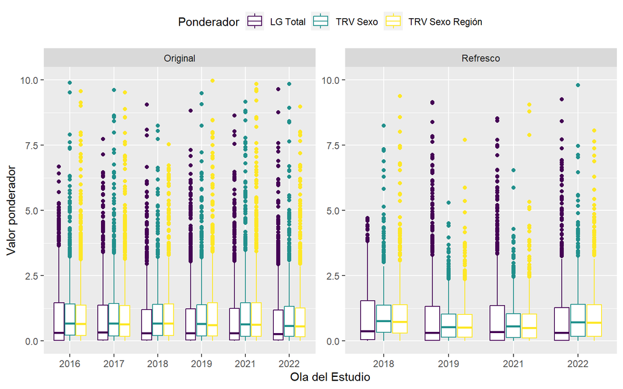

```r
grafo_box_var(vars_pred[names(vars_pred)=='Muestras'])
```

### Sexo

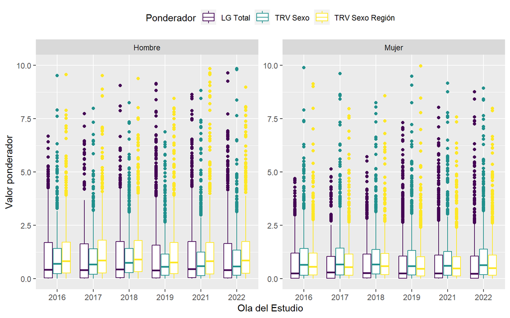

```r
grafo_box_var(vars_pred[names(vars_pred)=='Sexo'])
```

### Estratos

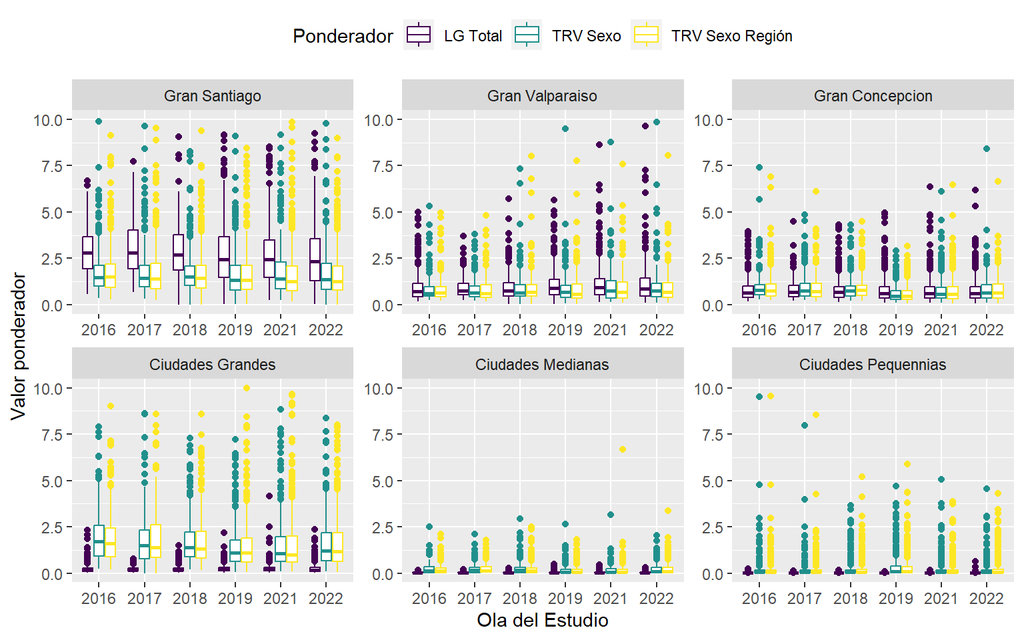

```r
grafo_box_var(vars_pred[names(vars_pred)=='Estratos'])
```

### Tramo Etario

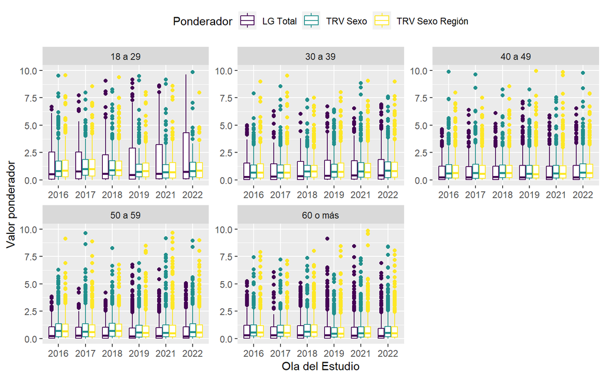

```r
grafo_box_var(vars_pred[names(vars_pred)=='Tramo Etario'])
```

### Educación

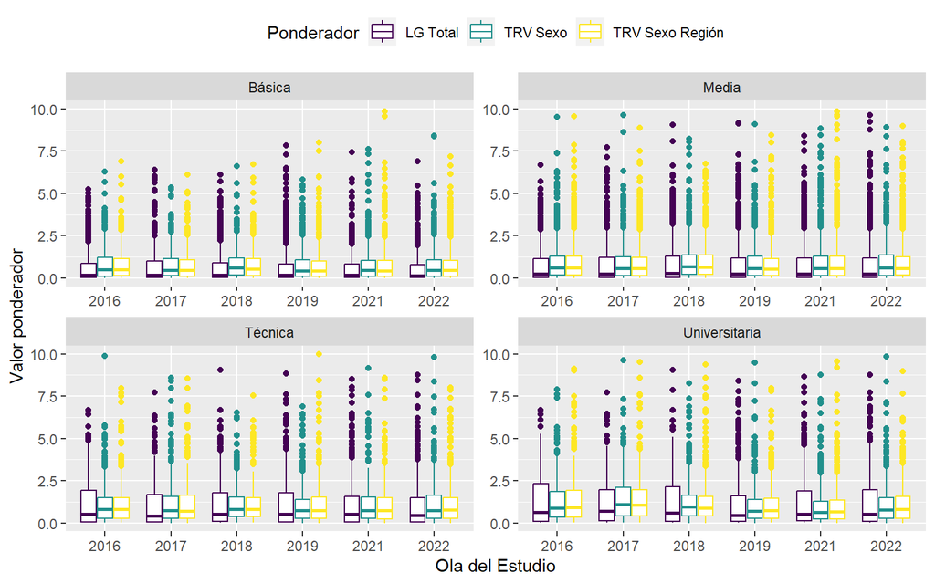

```r
grafo_box_var(vars_pred[names(vars_pred)=='Educación'])
```

## Aplicación de los pesos a variables

### Porcentaje síntomas depresivos según variables y pesos

#### Muestras

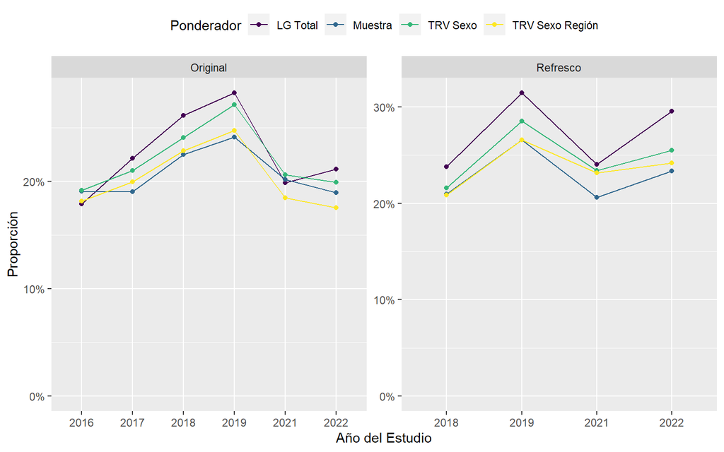

```r
grafo_pesos(vars_pred[names(vars_pred)=='Muestras'],'phq_s10')
```

#### Sexo

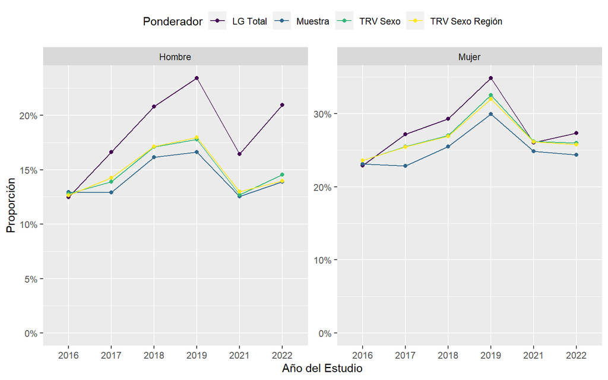

```r
grafo_pesos(vars_pred[names(vars_pred)=='Sexo'],'phq_s10')
```

#### Estratos

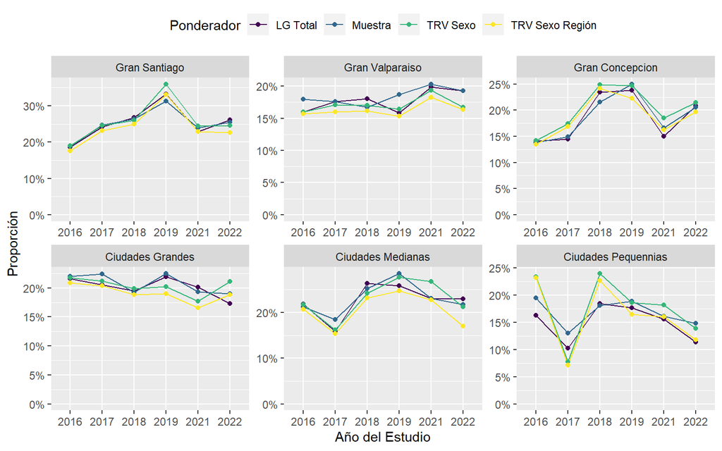

```r
grafo_pesos(vars_pred[names(vars_pred)=='Estratos'],'phq_s10')
```

#### Tramo Etario

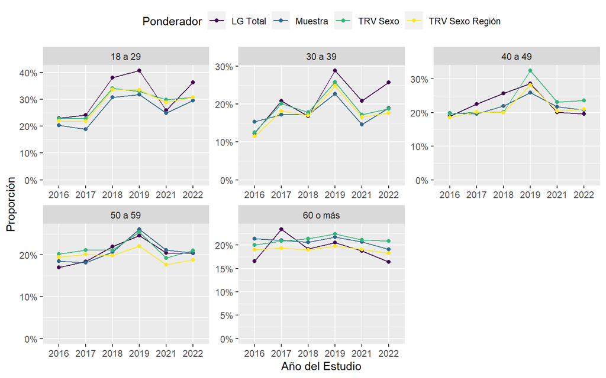

```r
grafo_pesos(vars_pred[names(vars_pred)=='Tramo Etario'],'phq_s10')
```

#### Educación

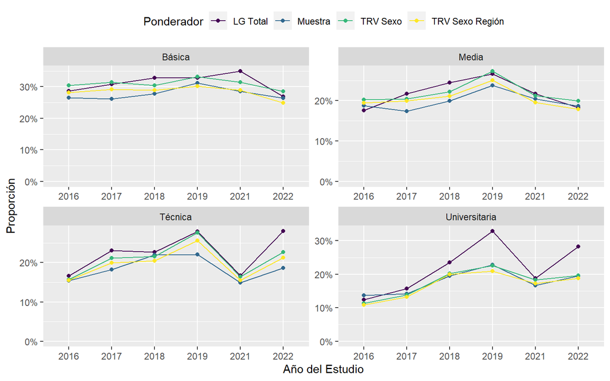

```r
grafo_pesos(vars_pred[names(vars_pred)=='Educación'],'phq_s10')
```

### Porcentaje de satisfacción con la democracia según variables y pesos

Se consideran los valor 4 y 5

#### Muestras

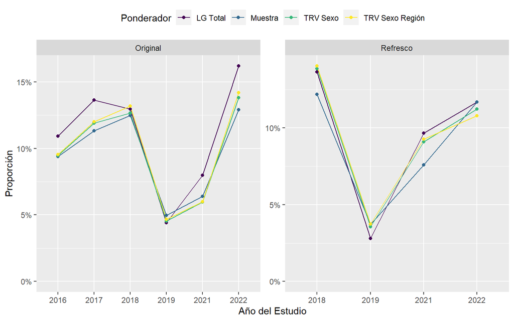

```r
grafo_pesos(vars_pred[names(vars_pred)=='Muestras'],'satis_demo')
```

#### Sexo

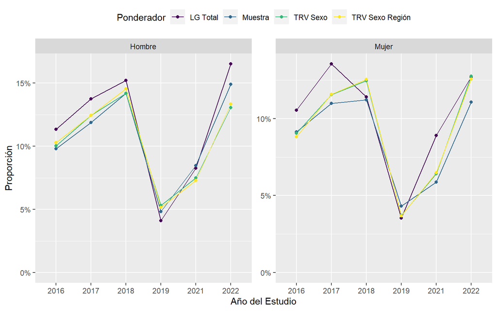

```r
grafo_pesos(vars_pred[names(vars_pred)=='Sexo'],'satis_demo')
```

#### Estratos

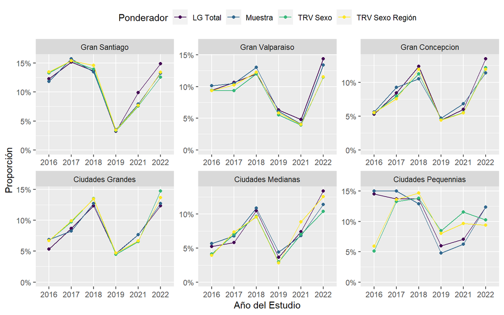

```r
grafo_pesos(vars_pred[names(vars_pred)=='Estratos'],'satis_demo')
```

#### Tramo Etario

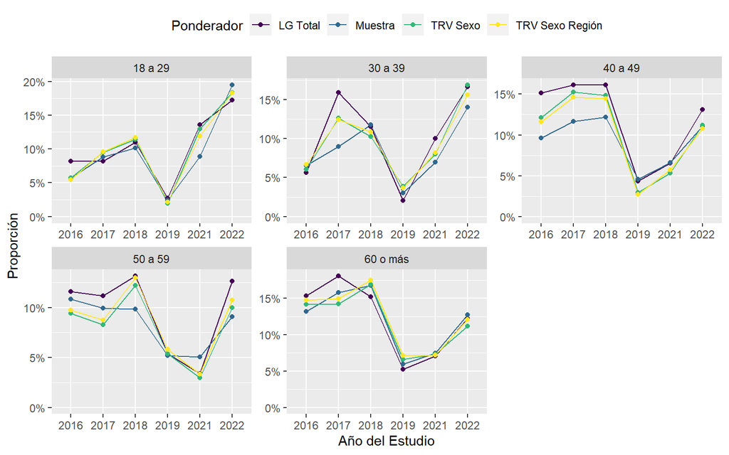

```r
grafo_pesos(vars_pred[names(vars_pred)=='Tramo Etario'],'satis_demo')
```

#### Educación

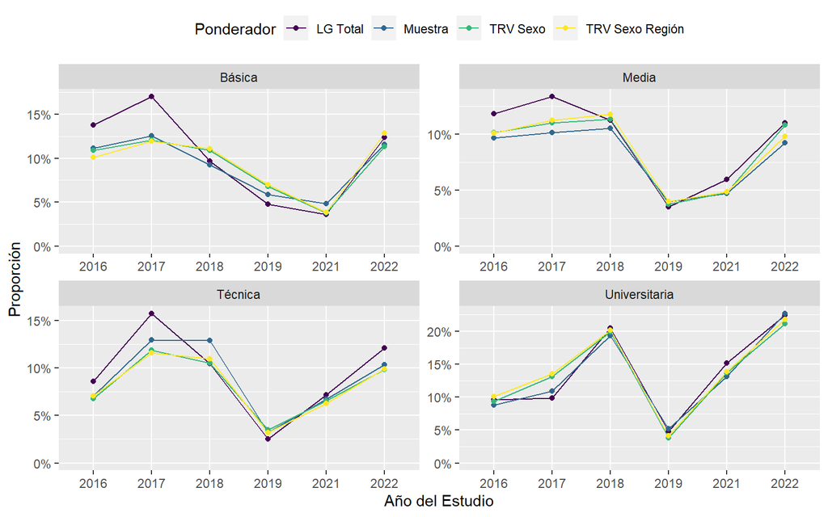

```r
grafo_pesos(vars_pred[names(vars_pred)=='Educación'],'satis_demo')
```

### Interés en política según variables y pesos

Se consideran los valor 4 y 5

#### Muestras

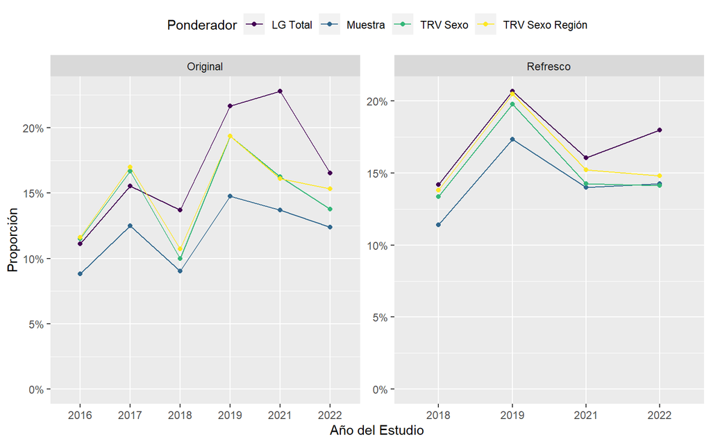

```r
grafo_pesos(vars_pred[names(vars_pred)=='Muestras'],'interes_poli')
```

#### Sexo

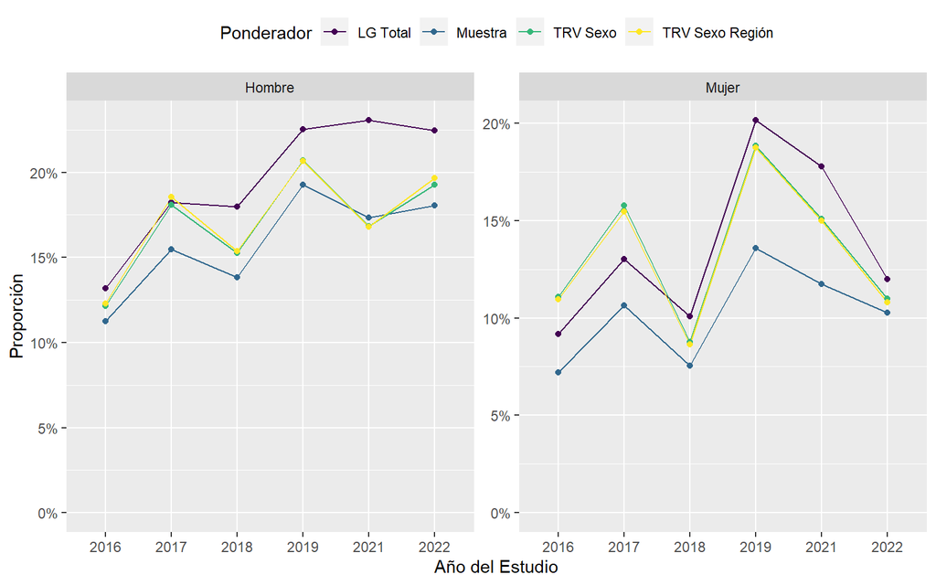

```r
grafo_pesos(vars_pred[names(vars_pred)=='Sexo'],'interes_poli')
```

#### Estratos

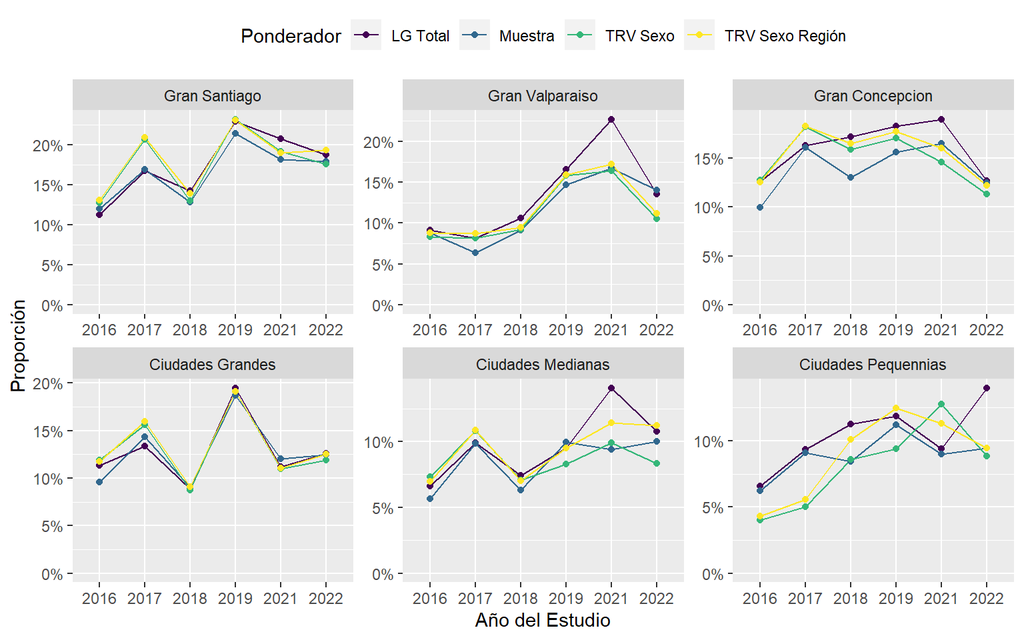

```r
grafo_pesos(vars_pred[names(vars_pred)=='Estratos'],'interes_poli')
```

#### Tramo Etario

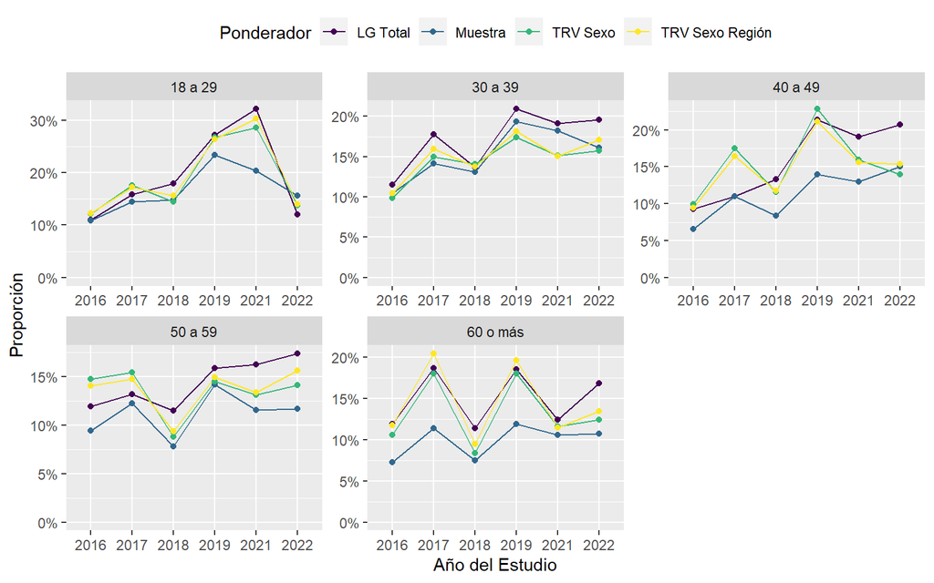

```r
grafo_pesos(vars_pred[names(vars_pred)=='Tramo Etario'],'interes_poli')
```

#### Educación

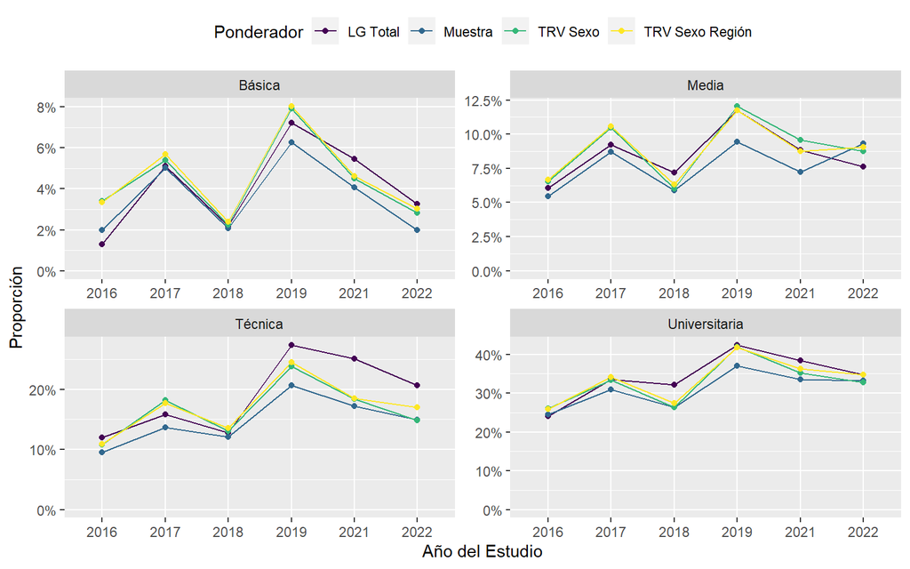

```r
grafo_pesos(vars_pred[names(vars_pred)=='Educación'],'interes_poli')
```

### Confianza social generalizada según variables y pesos

Se consideran el valor 2

#### Muestras

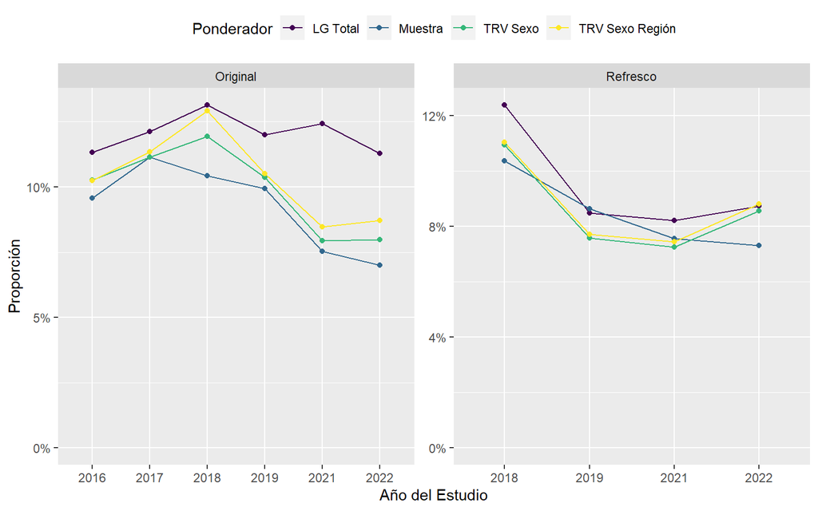

```r
grafo_pesos(vars_pred[names(vars_pred)=='Muestras'],'confianza')
```

#### Sexo

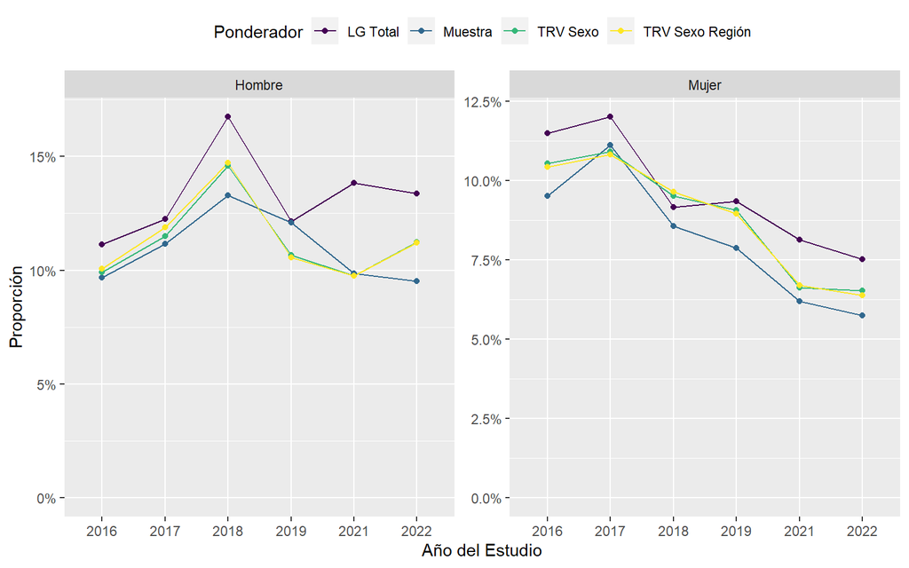

```r
grafo_pesos(vars_pred[names(vars_pred)=='Sexo'],'confianza')
```

#### Estratos

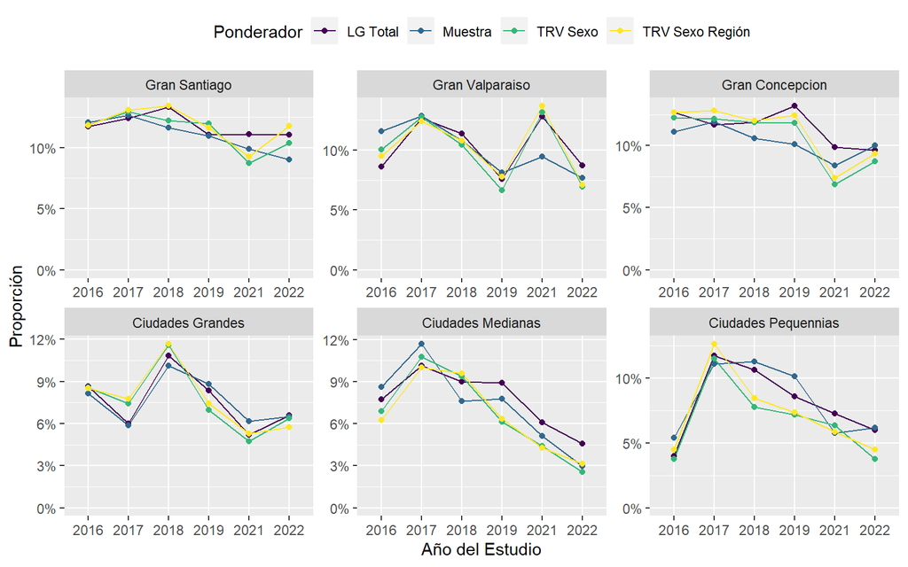

```r
grafo_pesos(vars_pred[names(vars_pred)=='Estratos'],'confianza')
```

#### Tramo Etario

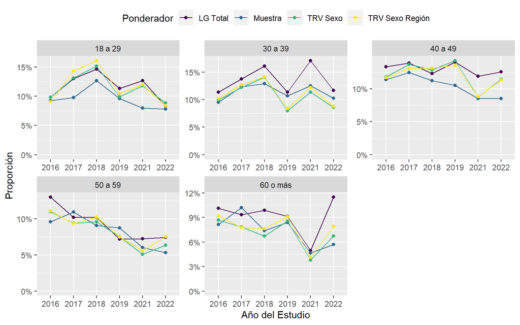

```r
grafo_pesos(vars_pred[names(vars_pred)=='Tramo Etario'],'confianza')
```

#### Educación

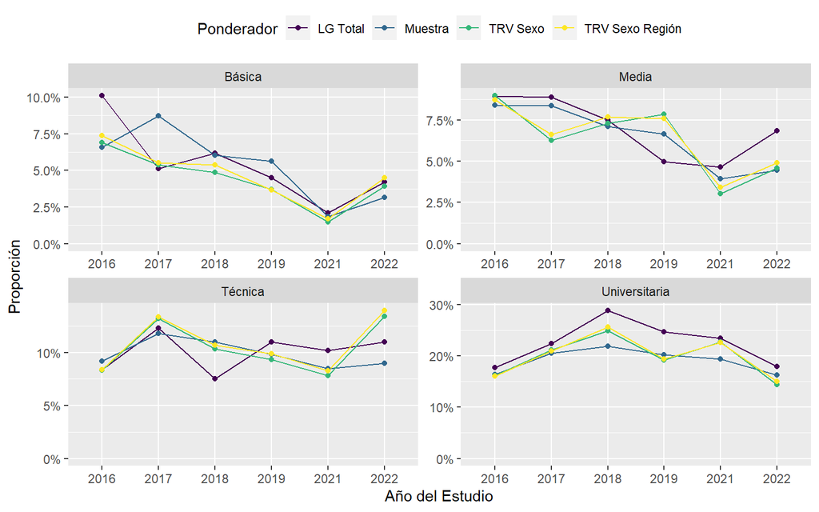

```r
grafo_pesos(vars_pred[names(vars_pred)=='Educación'],'confianza')
```

### Autoritarismo según variables y pesos

Se consideran los valor 4 y 5

#### Muestras

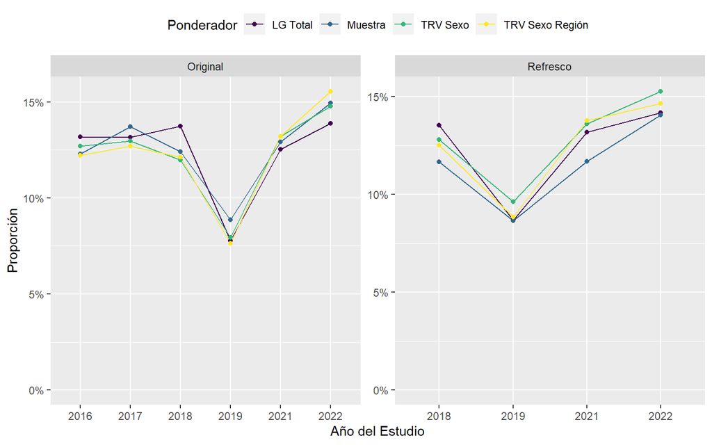

```r
grafo_pesos(vars_pred[names(vars_pred)=='Muestras'],'autori')
```

#### Sexo

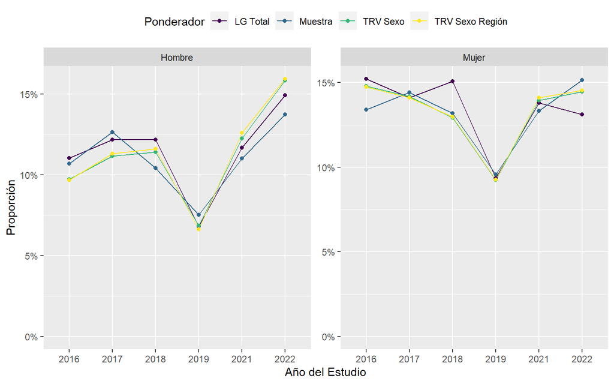

```r
grafo_pesos(vars_pred[names(vars_pred)=='Sexo'],'autori')
```